# Risk Factor Analysis

## Outcome Variable

**Outcome Variable:** haz

## Predictor Variables

**Intervention Variable:** birthlen

**Adjustment Set:**

- arm
- sex
- W_mage
- meducyrs
- feducyrs
- vagbrth
- single
- brthmon
- W_parity
- impsan
- delta_W_mage
- delta_meducyrs
- delta_feducyrs
- delta_vagbrth
- delta_single
- delta_brthmon
- delta_W_parity
- delta_impsan

## Stratifying Variables

The analysis was stratified on these variable(s):

- agecat
- studyid
- country

## Data Summary

| agecat | studyid | country | birthlen | n_cell | n |
| --- | --- | --- | --- | --- | --- |
| Birth | ki0047075b-MAL-ED | BANGLADESH | >=50 cm | 29 | 257 |
| Birth | ki0047075b-MAL-ED | BANGLADESH | <48 cm | 144 | 257 |
| Birth | ki0047075b-MAL-ED | BANGLADESH | [48-50) cm | 84 | 257 |
| Birth | ki0047075b-MAL-ED | BRAZIL | >=50 cm | 34 | 191 |
| Birth | ki0047075b-MAL-ED | BRAZIL | <48 cm | 80 | 191 |
| Birth | ki0047075b-MAL-ED | BRAZIL | [48-50) cm | 77 | 191 |
| Birth | ki0047075b-MAL-ED | INDIA | >=50 cm | 25 | 206 |
| Birth | ki0047075b-MAL-ED | INDIA | <48 cm | 107 | 206 |
| Birth | ki0047075b-MAL-ED | INDIA | [48-50) cm | 74 | 206 |
| Birth | ki0047075b-MAL-ED | NEPAL | >=50 cm | 38 | 173 |
| Birth | ki0047075b-MAL-ED | NEPAL | <48 cm | 69 | 173 |
| Birth | ki0047075b-MAL-ED | NEPAL | [48-50) cm | 66 | 173 |
| Birth | ki0047075b-MAL-ED | PERU | >=50 cm | 34 | 287 |
| Birth | ki0047075b-MAL-ED | PERU | <48 cm | 142 | 287 |
| Birth | ki0047075b-MAL-ED | PERU | [48-50) cm | 111 | 287 |
| Birth | ki0047075b-MAL-ED | SOUTH AFRICA | >=50 cm | 47 | 262 |
| Birth | ki0047075b-MAL-ED | SOUTH AFRICA | <48 cm | 112 | 262 |
| Birth | ki0047075b-MAL-ED | SOUTH AFRICA | [48-50) cm | 103 | 262 |
| Birth | ki0047075b-MAL-ED | TANZANIA, UNITED REPUBLIC OF | >=50 cm | 15 | 123 |
| Birth | ki0047075b-MAL-ED | TANZANIA, UNITED REPUBLIC OF | <48 cm | 57 | 123 |
| Birth | ki0047075b-MAL-ED | TANZANIA, UNITED REPUBLIC OF | [48-50) cm | 51 | 123 |
| Birth | ki1000108-CMC-V-BCS-2002 | INDIA | >=50 cm | 13 | 90 |
| Birth | ki1000108-CMC-V-BCS-2002 | INDIA | <48 cm | 37 | 90 |
| Birth | ki1000108-CMC-V-BCS-2002 | INDIA | [48-50) cm | 40 | 90 |
| Birth | ki1000108-IRC | INDIA | >=50 cm | 142 | 388 |
| Birth | ki1000108-IRC | INDIA | <48 cm | 108 | 388 |
| Birth | ki1000108-IRC | INDIA | [48-50) cm | 138 | 388 |
| Birth | ki1000109-EE | PAKISTAN | >=50 cm | 1 | 2 |
| Birth | ki1000109-EE | PAKISTAN | <48 cm | 1 | 2 |
| Birth | ki1000109-EE | PAKISTAN | [48-50) cm | 0 | 2 |

[output cut: 201 more lines]

The following strata were considered:

- agecat: 24 months, studyid: ki0047075b-MAL-ED, country: BANGLADESH
- agecat: 24 months, studyid: ki0047075b-MAL-ED, country: BRAZIL
- agecat: 24 months, studyid: ki0047075b-MAL-ED, country: INDIA
- agecat: 24 months, studyid: ki0047075b-MAL-ED, country: NEPAL
- agecat: 24 months, studyid: ki0047075b-MAL-ED, country: PERU
- agecat: 24 months, studyid: ki0047075b-MAL-ED, country: SOUTH AFRICA
- agecat: 24 months, studyid: ki0047075b-MAL-ED, country: TANZANIA, UNITED REPUBLIC OF
- agecat: 24 months, studyid: ki1000108-CMC-V-BCS-2002, country: INDIA
- agecat: 24 months, studyid: ki1000108-IRC, country: INDIA
- agecat: 24 months, studyid: ki1017093-NIH-Birth, country: BANGLADESH
- agecat: 24 months, studyid: ki1017093b-PROVIDE, country: BANGLADESH
- agecat: 24 months, studyid: ki1017093c-NIH-Crypto, country: BANGLADESH
- agecat: 24 months, studyid: ki1101329-Keneba, country: GAMBIA
- agecat: 24 months, studyid: ki1114097-CMIN, country: BANGLADESH
- agecat: 24 months, studyid: ki1114097-CMIN, country: PERU
- agecat: 24 months, studyid: ki1114097-CONTENT, country: PERU
- agecat: 24 months, studyid: ki1119695-PROBIT, country: BELARUS
- agecat: 24 months, studyid: ki1126311-ZVITAMBO, country: ZIMBABWE
- agecat: 24 months, studyid: ki1135781-COHORTS, country: GUATEMALA
- agecat: 24 months, studyid: ki1135781-COHORTS, country: INDIA
- agecat: 24 months, studyid: ki1135781-COHORTS, country: PHILIPPINES
- agecat: 24 months, studyid: kiGH5241-JiVitA-3, country: BANGLADESH
- agecat: 24 months, studyid: kiGH5241-JiVitA-4, country: BANGLADESH
- agecat: 6 months, studyid: ki0047075b-MAL-ED, country: BANGLADESH
- agecat: 6 months, studyid: ki0047075b-MAL-ED, country: BRAZIL
- agecat: 6 months, studyid: ki0047075b-MAL-ED, country: INDIA
- agecat: 6 months, studyid: ki0047075b-MAL-ED, country: NEPAL
- agecat: 6 months, studyid: ki0047075b-MAL-ED, country: PERU
- agecat: 6 months, studyid: ki0047075b-MAL-ED, country: SOUTH AFRICA
- agecat: 6 months, studyid: ki0047075b-MAL-ED, country: TANZANIA, UNITED REPUBLIC OF
- agecat: 6 months, studyid: ki1000108-CMC-V-BCS-2002, country: INDIA
- agecat: 6 months, studyid: ki1000108-IRC, country: INDIA
- agecat: 6 months, studyid: ki1000109-EE, country: PAKISTAN
- agecat: 6 months, studyid: ki1000109-ResPak, country: PAKISTAN
- agecat: 6 months, studyid: ki1000304b-SAS-CompFeed, country: INDIA
- agecat: 6 months, studyid: ki1017093-NIH-Birth, country: BANGLADESH
- agecat: 6 months, studyid: ki1017093b-PROVIDE, country: BANGLADESH
- agecat: 6 months, studyid: ki1017093c-NIH-Crypto, country: BANGLADESH
- agecat: 6 months, studyid: ki1101329-Keneba, country: GAMBIA
- agecat: 6 months, studyid: ki1114097-CMIN, country: BANGLADESH
- agecat: 6 months, studyid: ki1114097-CMIN, country: BRAZIL
- agecat: 6 months, studyid: ki1114097-CMIN, country: GUINEA-BISSAU
- agecat: 6 months, studyid: ki1114097-CMIN, country: PERU
- agecat: 6 months, studyid: ki1114097-CONTENT, country: PERU
- agecat: 6 months, studyid: ki1119695-PROBIT, country: BELARUS
- agecat: 6 months, studyid: ki1126311-ZVITAMBO, country: ZIMBABWE
- agecat: 6 months, studyid: ki1135781-COHORTS, country: GUATEMALA
- agecat: 6 months, studyid: ki1135781-COHORTS, country: INDIA
- agecat: 6 months, studyid: ki1135781-COHORTS, country: PHILIPPINES
- agecat: 6 months, studyid: kiGH5241-JiVitA-3, country: BANGLADESH
- agecat: 6 months, studyid: kiGH5241-JiVitA-4, country: BANGLADESH
- agecat: Birth, studyid: ki0047075b-MAL-ED, country: BANGLADESH
- agecat: Birth, studyid: ki0047075b-MAL-ED, country: BRAZIL
- agecat: Birth, studyid: ki0047075b-MAL-ED, country: INDIA
- agecat: Birth, studyid: ki0047075b-MAL-ED, country: NEPAL
- agecat: Birth, studyid: ki0047075b-MAL-ED, country: PERU
- agecat: Birth, studyid: ki0047075b-MAL-ED, country: SOUTH AFRICA
- agecat: Birth, studyid: ki0047075b-MAL-ED, country: TANZANIA, UNITED REPUBLIC OF
- agecat: Birth, studyid: ki1000108-CMC-V-BCS-2002, country: INDIA
- agecat: Birth, studyid: ki1000108-IRC, country: INDIA
- agecat: Birth, studyid: ki1000109-EE, country: PAKISTAN
- agecat: Birth, studyid: ki1000109-ResPak, country: PAKISTAN
- agecat: Birth, studyid: ki1000304b-SAS-CompFeed, country: INDIA
- agecat: Birth, studyid: ki1017093-NIH-Birth, country: BANGLADESH
- agecat: Birth, studyid: ki1017093c-NIH-Crypto, country: BANGLADESH
- agecat: Birth, studyid: ki1101329-Keneba, country: GAMBIA
- agecat: Birth, studyid: ki1114097-CMIN, country: BANGLADESH
- agecat: Birth, studyid: ki1114097-CMIN, country: BRAZIL
- agecat: Birth, studyid: ki1114097-CMIN, country: PERU
- agecat: Birth, studyid: ki1114097-CONTENT, country: PERU
- agecat: Birth, studyid: ki1119695-PROBIT, country: BELARUS
- agecat: Birth, studyid: ki1126311-ZVITAMBO, country: ZIMBABWE
- agecat: Birth, studyid: ki1135781-COHORTS, country: GUATEMALA
- agecat: Birth, studyid: ki1135781-COHORTS, country: INDIA
- agecat: Birth, studyid: ki1135781-COHORTS, country: PHILIPPINES
- agecat: Birth, studyid: kiGH5241-JiVitA-3, country: BANGLADESH
- agecat: Birth, studyid: kiGH5241-JiVitA-4, country: BANGLADESH

### Dropped Strata

Some strata were dropped due to rare outcomes:

- agecat: Birth, studyid: ki1000109-EE, country: PAKISTAN
- agecat: Birth, studyid: ki1000109-ResPak, country: PAKISTAN
- agecat: Birth, studyid: ki1017093c-NIH-Crypto, country: BANGLADESH
- agecat: Birth, studyid: ki1114097-CMIN, country: BANGLADESH
- agecat: Birth, studyid: ki1114097-CMIN, country: PERU
- agecat: Birth, studyid: ki1114097-CONTENT, country: PERU
- agecat: 6 months, studyid: ki1000109-ResPak, country: PAKISTAN
- agecat: 6 months, studyid: ki1114097-CMIN, country: BANGLADESH
- agecat: 6 months, studyid: ki1114097-CMIN, country: GUINEA-BISSAU
- agecat: 6 months, studyid: ki1114097-CMIN, country: PERU
- agecat: 6 months, studyid: ki1114097-CONTENT, country: PERU
- agecat: 24 months, studyid: ki1114097-CMIN, country: BANGLADESH
- agecat: 24 months, studyid: ki1114097-CMIN, country: PERU
- agecat: 24 months, studyid: ki1114097-CONTENT, country: PERU

## Methods Detail

We’re interested in the causal parameters $E[Y_a]$ for all values of $a \in \mathcal{A}$. These parameters represent the mean outcome if, possibly contrary to fact, we intervened to set all units to have $A=a$. Under the randomization and positivity assumptions, these are identified by the statistical parameters $\psi_a=E_W[E_{Y|A,W}(Y|A=a,W)]$. In addition, we’re interested in the mean of $Y$, $E[Y]$ under no intervention (the observed mean). We will estimate these parameters by using SuperLearner to fit the relevant likelihood factors – $E_{Y|A,W}(Y|A=a,W)$ and $p(A=a|W)$, and then updating our likelihood fit using a joint TMLE.

For unadjusted analyses ($W=\{\}$), initial likelihoods were estimated using Lrnr_glm to estimate the simple $E(Y|A)$ and Lrnr_mean to estimate $p(A)$. For adjusted analyses, a small library containing Lrnr_glmnet, Lrnr_xgboost, and Lrnr_mean was used.

Having estimated these parameters, we will then use the delta method to estimate relative risks and attributable risks relative to a prespecified baseline level of $A$.

# Results Detail

## Results Plots

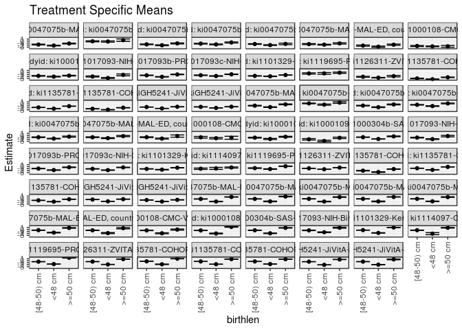

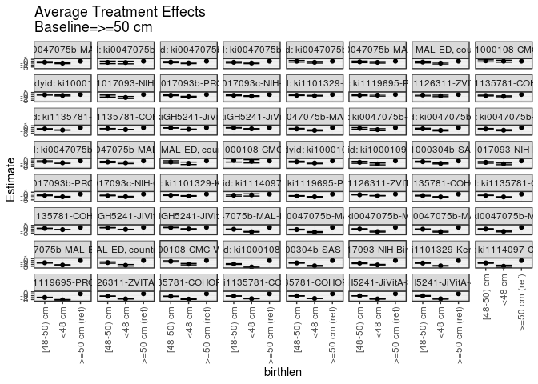

[figure not shown]

## Results Table

### Parameter: TSM

| agecat | studyid | country | intervention_level | baseline_level | estimate | ci_lower | ci_upper |
| --- | --- | --- | --- | --- | --- | --- | --- |
| Birth | ki0047075b-MAL-ED | BANGLADESH | >=50 cm | NA | 0.5340503 | 0.4402760 | 0.6278245 |
| Birth | ki0047075b-MAL-ED | BANGLADESH | <48 cm | NA | -1.7777899 | -1.8999609 | -1.6556190 |
| Birth | ki0047075b-MAL-ED | BANGLADESH | [48-50) cm | NA | -0.4788336 | -0.5564335 | -0.4012336 |
| Birth | ki0047075b-MAL-ED | BRAZIL | >=50 cm | NA | 0.7533289 | 0.5981909 | 0.9084670 |
| Birth | ki0047075b-MAL-ED | BRAZIL | <48 cm | NA | -1.7152239 | -1.8938543 | -1.5365936 |
| Birth | ki0047075b-MAL-ED | BRAZIL | [48-50) cm | NA | -0.4419362 | -0.5176775 | -0.3661950 |
| Birth | ki0047075b-MAL-ED | INDIA | >=50 cm | NA | 0.4715418 | 0.3251708 | 0.6179128 |
| Birth | ki0047075b-MAL-ED | INDIA | <48 cm | NA | -1.7714886 | -1.9106147 | -1.6323624 |
| Birth | ki0047075b-MAL-ED | INDIA | [48-50) cm | NA | -0.4186753 | -0.4961185 | -0.3412321 |
| Birth | ki0047075b-MAL-ED | NEPAL | >=50 cm | NA | 0.5457892 | 0.4538388 | 0.6377397 |
| Birth | ki0047075b-MAL-ED | NEPAL | <48 cm | NA | -1.7240755 | -1.9110974 | -1.5370536 |
| Birth | ki0047075b-MAL-ED | NEPAL | [48-50) cm | NA | -0.4303588 | -0.5141118 | -0.3466059 |
| Birth | ki0047075b-MAL-ED | PERU | >=50 cm | NA | 0.4721890 | 0.2986777 | 0.6457002 |
| Birth | ki0047075b-MAL-ED | PERU | <48 cm | NA | -1.6711348 | -1.7938202 | -1.5484494 |
| Birth | ki0047075b-MAL-ED | PERU | [48-50) cm | NA | -0.4177908 | -0.4802225 | -0.3553590 |
| Birth | ki0047075b-MAL-ED | SOUTH AFRICA | >=50 cm | NA | 0.7467766 | 0.5814633 | 0.9120899 |
| Birth | ki0047075b-MAL-ED | SOUTH AFRICA | <48 cm | NA | -1.6208168 | -1.7617558 | -1.4798778 |
| Birth | ki0047075b-MAL-ED | SOUTH AFRICA | [48-50) cm | NA | -0.3961124 | -0.4638089 | -0.3284159 |
| Birth | ki0047075b-MAL-ED | TANZANIA, UNITED REPUBLIC OF | >=50 cm | NA | 0.6002359 | 0.2803533 | 0.9201184 |
| Birth | ki0047075b-MAL-ED | TANZANIA, UNITED REPUBLIC OF | <48 cm | NA | -1.8753848 | -2.1340358 | -1.6167339 |
| Birth | ki0047075b-MAL-ED | TANZANIA, UNITED REPUBLIC OF | [48-50) cm | NA | -0.4656309 | -0.5664447 | -0.3648170 |
| Birth | ki1000108-CMC-V-BCS-2002 | INDIA | >=50 cm | NA | -0.0826525 | -0.3633748 | 0.1980697 |
| Birth | ki1000108-CMC-V-BCS-2002 | INDIA | <48 cm | NA | -1.9701077 | -2.2130568 | -1.7271585 |
| Birth | ki1000108-CMC-V-BCS-2002 | INDIA | [48-50) cm | NA | -0.5225428 | -0.6174004 | -0.4276852 |
| Birth | ki1000108-IRC | INDIA | >=50 cm | NA | 1.2762960 | 1.0954920 | 1.4571000 |
| Birth | ki1000108-IRC | INDIA | <48 cm | NA | -2.0776931 | -2.2807142 | -1.8746720 |
| Birth | ki1000108-IRC | INDIA | [48-50) cm | NA | -0.5311317 | -0.5879781 | -0.4742853 |
| Birth | ki1000304b-SAS-CompFeed | INDIA | >=50 cm | NA | 0.7888889 | 0.6737241 | 0.9040537 |
| Birth | ki1000304b-SAS-CompFeed | INDIA | <48 cm | NA | -1.9652419 | -2.1063873 | -1.8240965 |
| Birth | ki1000304b-SAS-CompFeed | INDIA | [48-50) cm | NA | -0.4483333 | -0.5274932 | -0.3691734 |

[output cut: 159 more lines]

### Parameter: E(Y)

| agecat | studyid | country | intervention_level | baseline_level | estimate | ci_lower | ci_upper |
| --- | --- | --- | --- | --- | --- | --- | --- |
| Birth | ki0047075b-MAL-ED | BANGLADESH | NA | NA | -1.0843969 | -1.2100768 | -0.9587169 |
| Birth | ki0047075b-MAL-ED | BRAZIL | NA | NA | -0.7609424 | -0.9178311 | -0.6040538 |
| Birth | ki0047075b-MAL-ED | INDIA | NA | NA | -1.0106311 | -1.1499962 | -0.8712660 |
| Birth | ki0047075b-MAL-ED | NEPAL | NA | NA | -0.7089017 | -0.8656064 | -0.5521971 |
| Birth | ki0047075b-MAL-ED | PERU | NA | NA | -0.9322300 | -1.0461262 | -0.8183337 |
| Birth | ki0047075b-MAL-ED | SOUTH AFRICA | NA | NA | -0.7266031 | -0.8549719 | -0.5982342 |
| Birth | ki0047075b-MAL-ED | TANZANIA, UNITED REPUBLIC OF | NA | NA | -0.9338211 | -1.1465079 | -0.7211344 |
| Birth | ki1000108-CMC-V-BCS-2002 | INDIA | NA | NA | -0.9654444 | -1.1742112 | -0.7566777 |
| Birth | ki1000108-IRC | INDIA | NA | NA | -0.3080412 | -0.4687931 | -0.1472894 |
| Birth | ki1000304b-SAS-CompFeed | INDIA | NA | NA | -1.3946524 | -1.5833612 | -1.2059436 |
| Birth | ki1017093-NIH-Birth | BANGLADESH | NA | NA | -0.5292857 | -0.8821252 | -0.1764462 |
| Birth | ki1101329-Keneba | GAMBIA | NA | NA | 0.0341467 | -0.0293905 | 0.0976838 |
| Birth | ki1114097-CMIN | BRAZIL | NA | NA | 0.0576522 | -0.1471825 | 0.2624869 |
| Birth | ki1119695-PROBIT | BELARUS | NA | NA | 1.3254775 | 1.1669293 | 1.4840258 |
| Birth | ki1126311-ZVITAMBO | ZIMBABWE | NA | NA | -0.5009660 | -0.5215391 | -0.4803930 |
| Birth | ki1135781-COHORTS | GUATEMALA | NA | NA | 0.1297300 | 0.0458017 | 0.2136584 |
| Birth | ki1135781-COHORTS | INDIA | NA | NA | -0.6698961 | -0.6980556 | -0.6417365 |
| Birth | ki1135781-COHORTS | PHILIPPINES | NA | NA | -0.2490492 | -0.2880580 | -0.2100404 |
| Birth | kiGH5241-JiVitA-3 | BANGLADESH | NA | NA | -1.5747407 | -1.5944667 | -1.5550147 |
| Birth | kiGH5241-JiVitA-4 | BANGLADESH | NA | NA | -1.4976642 | -1.5817349 | -1.4135935 |
| 6 months | ki0047075b-MAL-ED | BANGLADESH | NA | NA | -1.2022650 | -1.3221143 | -1.0824156 |
| 6 months | ki0047075b-MAL-ED | BRAZIL | NA | NA | 0.0285067 | -0.1269738 | 0.1839873 |
| 6 months | ki0047075b-MAL-ED | INDIA | NA | NA | -1.2237306 | -1.3563024 | -1.0911587 |
| 6 months | ki0047075b-MAL-ED | NEPAL | NA | NA | -0.5539669 | -0.6835584 | -0.4243753 |
| 6 months | ki0047075b-MAL-ED | PERU | NA | NA | -1.3183014 | -1.4284232 | -1.2081796 |
| 6 months | ki0047075b-MAL-ED | SOUTH AFRICA | NA | NA | -1.0867445 | -1.2250027 | -0.9484864 |
| 6 months | ki0047075b-MAL-ED | TANZANIA, UNITED REPUBLIC OF | NA | NA | -1.2464426 | -1.4177169 | -1.0751682 |
| 6 months | ki1000108-CMC-V-BCS-2002 | INDIA | NA | NA | -1.2850327 | -1.5453313 | -1.0247341 |
| 6 months | ki1000108-IRC | INDIA | NA | NA | -1.2263582 | -1.3620220 | -1.0906944 |
| 6 months | ki1000109-EE | PAKISTAN | NA | NA | -2.2224719 | -2.4728598 | -1.9720840 |
| 6 months | ki1000304b-SAS-CompFeed | INDIA | NA | NA | -1.4030363 | -1.4821426 | -1.3239299 |
| 6 months | ki1017093-NIH-Birth | BANGLADESH | NA | NA | -1.4277434 | -1.5827644 | -1.2727225 |
| 6 months | ki1017093b-PROVIDE | BANGLADESH | NA | NA | -1.0871041 | -1.1635539 | -1.0106543 |
| 6 months | ki1017093c-NIH-Crypto | BANGLADESH | NA | NA | -1.1986783 | -1.2700937 | -1.1272630 |
| 6 months | ki1101329-Keneba | GAMBIA | NA | NA | -0.9034101 | -0.9602836 | -0.8465366 |
| 6 months | ki1114097-CMIN | BRAZIL | NA | NA | -0.6919231 | -0.9005727 | -0.4832735 |
| 6 months | ki1119695-PROBIT | BELARUS | NA | NA | 0.1069986 | 0.0122286 | 0.2017686 |
| 6 months | ki1126311-ZVITAMBO | ZIMBABWE | NA | NA | -0.8901030 | -0.9161931 | -0.8640129 |
| 6 months | ki1135781-COHORTS | GUATEMALA | NA | NA | -1.7553052 | -1.8330182 | -1.6775923 |
| 6 months | ki1135781-COHORTS | INDIA | NA | NA | -0.9973610 | -1.0266429 | -0.9680792 |
| 6 months | ki1135781-COHORTS | PHILIPPINES | NA | NA | -1.1429137 | -1.1848624 | -1.1009651 |
| 6 months | kiGH5241-JiVitA-3 | BANGLADESH | NA | NA | -1.3106391 | -1.3337645 | -1.2875137 |
| 6 months | kiGH5241-JiVitA-4 | BANGLADESH | NA | NA | -1.3464316 | -1.3887462 | -1.3041170 |
| 24 months | ki0047075b-MAL-ED | BANGLADESH | NA | NA | -1.9335507 | -2.0606304 | -1.8064710 |
| 24 months | ki0047075b-MAL-ED | BRAZIL | NA | NA | -0.0454676 | -0.2306672 | 0.1397320 |
| 24 months | ki0047075b-MAL-ED | INDIA | NA | NA | -1.8062772 | -1.9488106 | -1.6637437 |
| 24 months | ki0047075b-MAL-ED | NEPAL | NA | NA | -1.2952424 | -1.4309104 | -1.1595745 |
| 24 months | ki0047075b-MAL-ED | PERU | NA | NA | -1.7348953 | -1.8589497 | -1.6108409 |
| 24 months | ki0047075b-MAL-ED | SOUTH AFRICA | NA | NA | -1.6101741 | -1.7576350 | -1.4627133 |
| 24 months | ki0047075b-MAL-ED | TANZANIA, UNITED REPUBLIC OF | NA | NA | -2.4650971 | -2.6626390 | -2.2675551 |
| 24 months | ki1000108-CMC-V-BCS-2002 | INDIA | NA | NA | -2.4847115 | -2.6420148 | -2.3274082 |
| 24 months | ki1000108-IRC | INDIA | NA | NA | -1.7718205 | -1.8683675 | -1.6752735 |
| 24 months | ki1017093-NIH-Birth | BANGLADESH | NA | NA | -2.2364903 | -2.4267511 | -2.0462295 |
| 24 months | ki1017093b-PROVIDE | BANGLADESH | NA | NA | -1.5861179 | -1.6693668 | -1.5028689 |
| 24 months | ki1017093c-NIH-Crypto | BANGLADESH | NA | NA | -1.4295331 | -1.5127726 | -1.3462935 |
| 24 months | ki1101329-Keneba | GAMBIA | NA | NA | -1.5419019 | -1.6041979 | -1.4796059 |
| 24 months | ki1119695-PROBIT | BELARUS | NA | NA | -0.1314048 | -0.4282725 | 0.1654630 |
| 24 months | ki1126311-ZVITAMBO | ZIMBABWE | NA | NA | -2.4044989 | -2.5203692 | -2.2886286 |
| 24 months | ki1135781-COHORTS | GUATEMALA | NA | NA | -2.8321530 | -2.9208502 | -2.7434558 |
| 24 months | ki1135781-COHORTS | INDIA | NA | NA | -1.9065763 | -1.9410803 | -1.8720724 |
| 24 months | ki1135781-COHORTS | PHILIPPINES | NA | NA | -2.3915397 | -2.4363201 | -2.3467593 |
| 24 months | kiGH5241-JiVitA-3 | BANGLADESH | NA | NA | -2.0116189 | -2.0393361 | -1.9839017 |
| 24 months | kiGH5241-JiVitA-4 | BANGLADESH | NA | NA | -1.7492977 | -1.7876816 | -1.7109138 |

### Parameter: ATE

| agecat | studyid | country | intervention_level | baseline_level | estimate | ci_lower | ci_upper |
| --- | --- | --- | --- | --- | --- | --- | --- |
| Birth | ki0047075b-MAL-ED | BANGLADESH | >=50 cm | >=50 cm | 0.0000000 | 0.0000000 | 0.0000000 |
| Birth | ki0047075b-MAL-ED | BANGLADESH | <48 cm | >=50 cm | -2.3118402 | -2.4660884 | -2.1575920 |
| Birth | ki0047075b-MAL-ED | BANGLADESH | [48-50) cm | >=50 cm | -1.0128838 | -1.1347541 | -0.8910135 |
| Birth | ki0047075b-MAL-ED | BRAZIL | >=50 cm | >=50 cm | 0.0000000 | 0.0000000 | 0.0000000 |
| Birth | ki0047075b-MAL-ED | BRAZIL | <48 cm | >=50 cm | -2.4685529 | -2.7076964 | -2.2294093 |
| Birth | ki0047075b-MAL-ED | BRAZIL | [48-50) cm | >=50 cm | -1.1952652 | -1.3693357 | -1.0211946 |
| Birth | ki0047075b-MAL-ED | INDIA | >=50 cm | >=50 cm | 0.0000000 | 0.0000000 | 0.0000000 |
| Birth | ki0047075b-MAL-ED | INDIA | <48 cm | >=50 cm | -2.2430304 | -2.4454291 | -2.0406317 |
| Birth | ki0047075b-MAL-ED | INDIA | [48-50) cm | >=50 cm | -0.8902171 | -1.0559606 | -0.7244736 |
| Birth | ki0047075b-MAL-ED | NEPAL | >=50 cm | >=50 cm | 0.0000000 | 0.0000000 | 0.0000000 |
| Birth | ki0047075b-MAL-ED | NEPAL | <48 cm | >=50 cm | -2.2698647 | -2.4797578 | -2.0599716 |
| Birth | ki0047075b-MAL-ED | NEPAL | [48-50) cm | >=50 cm | -0.9761481 | -1.0992023 | -0.8530938 |
| Birth | ki0047075b-MAL-ED | PERU | >=50 cm | >=50 cm | 0.0000000 | 0.0000000 | 0.0000000 |
| Birth | ki0047075b-MAL-ED | PERU | <48 cm | >=50 cm | -2.1433238 | -2.3547886 | -1.9318590 |
| Birth | ki0047075b-MAL-ED | PERU | [48-50) cm | >=50 cm | -0.8899797 | -1.0742238 | -0.7057357 |
| Birth | ki0047075b-MAL-ED | SOUTH AFRICA | >=50 cm | >=50 cm | 0.0000000 | 0.0000000 | 0.0000000 |
| Birth | ki0047075b-MAL-ED | SOUTH AFRICA | <48 cm | >=50 cm | -2.3675934 | -2.5850374 | -2.1501494 |
| Birth | ki0047075b-MAL-ED | SOUTH AFRICA | [48-50) cm | >=50 cm | -1.1428890 | -1.3215947 | -0.9641833 |
| Birth | ki0047075b-MAL-ED | TANZANIA, UNITED REPUBLIC OF | >=50 cm | >=50 cm | 0.0000000 | 0.0000000 | 0.0000000 |
| Birth | ki0047075b-MAL-ED | TANZANIA, UNITED REPUBLIC OF | <48 cm | >=50 cm | -2.4756207 | -2.8901181 | -2.0611234 |
| Birth | ki0047075b-MAL-ED | TANZANIA, UNITED REPUBLIC OF | [48-50) cm | >=50 cm | -1.0658668 | -1.4033077 | -0.7284259 |
| Birth | ki1000108-CMC-V-BCS-2002 | INDIA | >=50 cm | >=50 cm | 0.0000000 | 0.0000000 | 0.0000000 |
| Birth | ki1000108-CMC-V-BCS-2002 | INDIA | <48 cm | >=50 cm | -1.8874551 | -2.2561007 | -1.5188096 |
| Birth | ki1000108-CMC-V-BCS-2002 | INDIA | [48-50) cm | >=50 cm | -0.4398903 | -0.7366370 | -0.1431435 |
| Birth | ki1000108-IRC | INDIA | >=50 cm | >=50 cm | 0.0000000 | 0.0000000 | 0.0000000 |
| Birth | ki1000108-IRC | INDIA | <48 cm | >=50 cm | -3.3539891 | -3.6259824 | -3.0819958 |
| Birth | ki1000108-IRC | INDIA | [48-50) cm | >=50 cm | -1.8074277 | -1.9974694 | -1.6173860 |
| Birth | ki1000304b-SAS-CompFeed | INDIA | >=50 cm | >=50 cm | 0.0000000 | 0.0000000 | 0.0000000 |
| Birth | ki1000304b-SAS-CompFeed | INDIA | <48 cm | >=50 cm | -2.7541308 | -2.9718565 | -2.5364052 |
| Birth | ki1000304b-SAS-CompFeed | INDIA | [48-50) cm | >=50 cm | -1.2372222 | -1.3611186 | -1.1133259 |

[output cut: 159 more lines]

### Parameter: PAR

| agecat | studyid | country | intervention_level | baseline_level | estimate | ci_lower | ci_upper |
| --- | --- | --- | --- | --- | --- | --- | --- |
| Birth | ki0047075b-MAL-ED | BANGLADESH | >=50 cm | NA | -1.6184471 | -1.7688249 | -1.4680694 |
| Birth | ki0047075b-MAL-ED | BRAZIL | >=50 cm | NA | -1.5142713 | -1.7151258 | -1.3134169 |
| Birth | ki0047075b-MAL-ED | INDIA | >=50 cm | NA | -1.4821729 | -1.6713059 | -1.2930398 |
| Birth | ki0047075b-MAL-ED | NEPAL | >=50 cm | NA | -1.2546909 | -1.4246258 | -1.0847561 |
| Birth | ki0047075b-MAL-ED | PERU | >=50 cm | NA | -1.4044189 | -1.5958747 | -1.2129632 |
| Birth | ki0047075b-MAL-ED | SOUTH AFRICA | >=50 cm | NA | -1.4733796 | -1.6585499 | -1.2882094 |
| Birth | ki0047075b-MAL-ED | TANZANIA, UNITED REPUBLIC OF | >=50 cm | NA | -1.5340570 | -1.8892472 | -1.1788669 |
| Birth | ki1000108-CMC-V-BCS-2002 | INDIA | >=50 cm | NA | -0.8827919 | -1.1915647 | -0.5740191 |
| Birth | ki1000108-IRC | INDIA | >=50 cm | NA | -1.5843372 | -1.7712468 | -1.3974277 |
| Birth | ki1000304b-SAS-CompFeed | INDIA | >=50 cm | NA | -2.1835413 | -2.4502376 | -1.9168450 |
| Birth | ki1017093-NIH-Birth | BANGLADESH | >=50 cm | NA | -1.3821429 | -1.7703499 | -0.9939358 |
| Birth | ki1101329-Keneba | GAMBIA | >=50 cm | NA | -0.9416793 | -1.0058455 | -0.8775132 |
| Birth | ki1114097-CMIN | BRAZIL | >=50 cm | NA | -0.7715782 | -0.9725990 | -0.5705574 |
| Birth | ki1119695-PROBIT | BELARUS | >=50 cm | NA | -0.1893233 | -0.2328187 | -0.1458279 |
| Birth | ki1126311-ZVITAMBO | ZIMBABWE | >=50 cm | NA | -1.3290554 | -1.3543136 | -1.3037972 |
| Birth | ki1135781-COHORTS | GUATEMALA | >=50 cm | NA | -0.9191288 | -1.0044110 | -0.8338466 |
| Birth | ki1135781-COHORTS | INDIA | >=50 cm | NA | -1.5082055 | -1.5470534 | -1.4693576 |
| Birth | ki1135781-COHORTS | PHILIPPINES | >=50 cm | NA | -1.0397932 | -1.0825449 | -0.9970415 |
| Birth | kiGH5241-JiVitA-3 | BANGLADESH | >=50 cm | NA | -2.2255014 | -2.2724758 | -2.1785270 |
| Birth | kiGH5241-JiVitA-4 | BANGLADESH | >=50 cm | NA | -2.1863002 | -2.3531290 | -2.0194715 |
| 6 months | ki0047075b-MAL-ED | BANGLADESH | >=50 cm | NA | -0.9604122 | -1.1772259 | -0.7435986 |
| 6 months | ki0047075b-MAL-ED | BRAZIL | >=50 cm | NA | -0.6108473 | -0.9774541 | -0.2442406 |
| 6 months | ki0047075b-MAL-ED | INDIA | >=50 cm | NA | -0.9359459 | -1.1693286 | -0.7025633 |
| 6 months | ki0047075b-MAL-ED | NEPAL | >=50 cm | NA | -0.7691529 | -0.9629901 | -0.5753158 |
| 6 months | ki0047075b-MAL-ED | PERU | >=50 cm | NA | -0.6224784 | -0.8806040 | -0.3643528 |
| 6 months | ki0047075b-MAL-ED | SOUTH AFRICA | >=50 cm | NA | -0.6604994 | -0.9436058 | -0.3773929 |
| 6 months | ki0047075b-MAL-ED | TANZANIA, UNITED REPUBLIC OF | >=50 cm | NA | -0.8397882 | -1.3982736 | -0.2813028 |
| 6 months | ki1000108-CMC-V-BCS-2002 | INDIA | >=50 cm | NA | -0.0157900 | -0.7136991 | 0.6821191 |
| 6 months | ki1000108-IRC | INDIA | >=50 cm | NA | -0.4647290 | -0.6386704 | -0.2907876 |
| 6 months | ki1000109-EE | PAKISTAN | >=50 cm | NA | -0.9194489 | -1.2718938 | -0.5670041 |
| 6 months | ki1000304b-SAS-CompFeed | INDIA | >=50 cm | NA | -0.8404522 | -1.0343433 | -0.6465612 |
| 6 months | ki1017093-NIH-Birth | BANGLADESH | >=50 cm | NA | -1.0209312 | -1.3789279 | -0.6629345 |
| 6 months | ki1017093b-PROVIDE | BANGLADESH | >=50 cm | NA | -0.7622577 | -0.8873307 | -0.6371847 |
| 6 months | ki1017093c-NIH-Crypto | BANGLADESH | >=50 cm | NA | -0.7932175 | -0.8995574 | -0.6868775 |
| 6 months | ki1101329-Keneba | GAMBIA | >=50 cm | NA | -0.3609893 | -0.4181025 | -0.3038761 |
| 6 months | ki1114097-CMIN | BRAZIL | >=50 cm | NA | -0.2573643 | -0.4443537 | -0.0703749 |
| 6 months | ki1119695-PROBIT | BELARUS | >=50 cm | NA | -0.0914667 | -0.1148093 | -0.0681241 |
| 6 months | ki1126311-ZVITAMBO | ZIMBABWE | >=50 cm | NA | -0.4012650 | -0.4400560 | -0.3624740 |
| 6 months | ki1135781-COHORTS | GUATEMALA | >=50 cm | NA | -0.5207830 | -0.5972667 | -0.4442993 |
| 6 months | ki1135781-COHORTS | INDIA | >=50 cm | NA | -0.8601969 | -0.9101295 | -0.8102643 |
| 6 months | ki1135781-COHORTS | PHILIPPINES | >=50 cm | NA | -0.5219718 | -0.5747514 | -0.4691923 |
| 6 months | kiGH5241-JiVitA-3 | BANGLADESH | >=50 cm | NA | -0.7325333 | -0.7767584 | -0.6883083 |
| 6 months | kiGH5241-JiVitA-4 | BANGLADESH | >=50 cm | NA | -0.4297637 | -0.4914193 | -0.3681082 |
| 24 months | ki0047075b-MAL-ED | BANGLADESH | >=50 cm | NA | -0.7140776 | -0.9441203 | -0.4840349 |
| 24 months | ki0047075b-MAL-ED | BRAZIL | >=50 cm | NA | -0.5388507 | -1.0961107 | 0.0184093 |
| 24 months | ki0047075b-MAL-ED | INDIA | >=50 cm | NA | -0.6446335 | -0.9057926 | -0.3834743 |
| 24 months | ki0047075b-MAL-ED | NEPAL | >=50 cm | NA | -0.5993800 | -0.8472219 | -0.3515381 |
| 24 months | ki0047075b-MAL-ED | PERU | >=50 cm | NA | -0.3246302 | -0.6828330 | 0.0335726 |
| 24 months | ki0047075b-MAL-ED | SOUTH AFRICA | >=50 cm | NA | -0.4333321 | -0.7307736 | -0.1358907 |
| 24 months | ki0047075b-MAL-ED | TANZANIA, UNITED REPUBLIC OF | >=50 cm | NA | -0.6582893 | -1.0025863 | -0.3139924 |
| 24 months | ki1000108-CMC-V-BCS-2002 | INDIA | >=50 cm | NA | 0.1582573 | -0.2587102 | 0.5752248 |
| 24 months | ki1000108-IRC | INDIA | >=50 cm | NA | -0.1906745 | -0.3212450 | -0.0601039 |
| 24 months | ki1017093-NIH-Birth | BANGLADESH | >=50 cm | NA | -1.0417018 | -1.4725098 | -0.6108939 |
| 24 months | ki1017093b-PROVIDE | BANGLADESH | >=50 cm | NA | -0.5959469 | -0.7303138 | -0.4615800 |
| 24 months | ki1017093c-NIH-Crypto | BANGLADESH | >=50 cm | NA | -0.5080931 | -0.6294822 | -0.3867041 |
| 24 months | ki1101329-Keneba | GAMBIA | >=50 cm | NA | -0.2605067 | -0.3220802 | -0.1989332 |
| 24 months | ki1119695-PROBIT | BELARUS | >=50 cm | NA | -0.0316577 | -0.0587684 | -0.0045469 |
| 24 months | ki1126311-ZVITAMBO | ZIMBABWE | >=50 cm | NA | -0.5569216 | -0.8968036 | -0.2170395 |
| 24 months | ki1135781-COHORTS | GUATEMALA | >=50 cm | NA | -0.3877775 | -0.4815886 | -0.2939663 |
| 24 months | ki1135781-COHORTS | INDIA | >=50 cm | NA | -0.7392694 | -0.8013030 | -0.6772359 |
| 24 months | ki1135781-COHORTS | PHILIPPINES | >=50 cm | NA | -0.4548310 | -0.5122692 | -0.3973928 |
| 24 months | kiGH5241-JiVitA-3 | BANGLADESH | >=50 cm | NA | -0.5554225 | -0.6197182 | -0.4911269 |
| 24 months | kiGH5241-JiVitA-4 | BANGLADESH | >=50 cm | NA | -0.3031018 | -0.3610519 | -0.2451517 |